# Reliability Analyses NHB3

Youssef Amin and Angelika Stefan

## Load packages

```r
library(Bayesrel)
library(knitr)
```

## Read in data

```r
nhb3 <- read.csv('../../data/nhb3_processed.csv')
```

## Compute scale reliability scores

- Composite political orientation
- Mean intergroup bias

**Composite political orientation**

The composite political orientation scale is computed as the average of the social and economic conservativeness scale (SEC) as well as three items measuring economic, social, and political orientation. We compute Cronbach’s alpha for the SEC and the composite political orientation scale in the frequentist and Bayesian paradigm.

```r
# SEC reliability
strel(nhb3[,c("RC_SECS_1", paste0("SECS_", 2:4), "RC_SECS_5", paste0("SECS_", 6:12))], estimates = "alpha")
```

```
## Call:
## strel(data = nhb3[, c("RC_SECS_1", paste0("SECS_", 2:4), "RC_SECS_5",
##     paste0("SECS_", 6:12))], estimates = "alpha")
##
## Estimates of Single-Test Reliability Measures:
##
##             point est  95 % CI lower  95% CI upper
## Bayes_alpha   0.89115        0.88307       0.89960
## freq_alpha    0.89122        0.88261       0.89934
```

```r
# Composite political orientation scale
strel(nhb3[, c("z_mean_SECS", "z_EconOrient", "z_SocOrient", "z_PolOrient")], estimates = "alpha")
```

```
## Call:
## strel(data = nhb3[, c("z_mean_SECS", "z_EconOrient", "z_SocOrient",
##     "z_PolOrient")], estimates = "alpha")
##
## Estimates of Single-Test Reliability Measures:
##
##             point est  95 % CI lower  95% CI upper
## Bayes_alpha   0.94488        0.93939       0.94997
## freq_alpha    0.94487        0.93958       0.94978
```

Both scales show excellent internal consistency.

### Mean intergroup bias

The mean intergroup bias scale is composed of three variables:

- The difference in ingroup and outgroup evaluative trait ratings (each in itself a rating scale with 6 items)
- The difference in points allocated to ingroup and outgroup in the Tajfel matrices
- The difference in ingroup and outgroup identification

We compute Cronbach’s alpha for the trait rating scales and the intergroup bias scale in the frequentist and Bayesian paradigm.

```r
# Ingroup Evaluative Traits
strel(nhb3[, c("RC_InTraits_1","InTraits_2","InTraits_3", "RC_InTraits_4","InTraits_5","RC_InTraits_6")], estimates = "alpha")
```

```
## Call:
## strel(data = nhb3[, c("RC_InTraits_1", "InTraits_2", "InTraits_3",
##     "RC_InTraits_4", "InTraits_5", "RC_InTraits_6")], estimates = "alpha")
##
## Estimates of Single-Test Reliability Measures:
##
##             point est  95 % CI lower  95% CI upper
## Bayes_alpha   0.86292        0.84954       0.87377
## freq_alpha    0.86315        0.85049       0.87493
```

```r
# Outgroup Evaluative Traits
strel(nhb3[, c("RC_OutTraits_1","OutTraits_2","OutTraits_3", "RC_OutTraits_4","OutTraits_5","RC_OutTraits_6")], estimates = "alpha")
```

```
## Call:
## strel(data = nhb3[, c("RC_OutTraits_1", "OutTraits_2", "OutTraits_3",
##     "RC_OutTraits_4", "OutTraits_5", "RC_OutTraits_6")], estimates = "alpha")
##
## Estimates of Single-Test Reliability Measures:
##
##             point est  95 % CI lower  95% CI upper
## Bayes_alpha   0.80919        0.79040       0.82814
## freq_alpha    0.79493        0.77591       0.81263
```

Both the ingroup and outgroup evaluative trait measure have good internal consistency.

```r
# Mean intergroup bias
strel(nhb3[, c("z_total_ingroup_minus_outgroup_points", "z_ingroup_minus_outgroup_traits_positive", "z_ingroup_minus_outgroup_identify")], estimates = "alpha")
```

```
## Call:
## strel(data = nhb3[, c("z_total_ingroup_minus_outgroup_points",
##     "z_ingroup_minus_outgroup_traits_positive", "z_ingroup_minus_outgroup_identify")],
##     estimates = "alpha")
##
## Estimates of Single-Test Reliability Measures:
##
##             point est  95 % CI lower  95% CI upper
## Bayes_alpha   0.52187        0.47827       0.56616
## freq_alpha    0.52285        0.47629       0.56594
```

Same as in Study 1, the mean intergroup bias measure has inadequate internal consistency ($\alpha$ << .70). We will therefore compute all analyses with the three variables separately as exploratory analyses.

Below is a correlation table that shows the correlations between the items:

```r
kable(data.frame(cor(nhb3[, c("z_total_ingroup_minus_outgroup_points",
                   "z_ingroup_minus_outgroup_traits_positive",
                   "z_ingroup_minus_outgroup_identify")], use = "pairwise"),
                 row.names = c("Points", "Traits", "Identification")),
      digits = 3,
      col.names = c("Points", "Traits", "Identification"),
      caption = "Prolific Sample")
```

Prolific Sample

|  | Points | Traits | Identification |
| --- | --- | --- | --- |
| Points | 1.000 | 0.236 | 0.271 |
| Traits | 0.236 | 1.000 | 0.295 |
| Identification | 0.271 | 0.295 | 1.000 |

And a correlation plot showing that a lack of variability in the variables is not the reason for the low correlations and that there are no discernable non-linear bivariate patterns in the data.

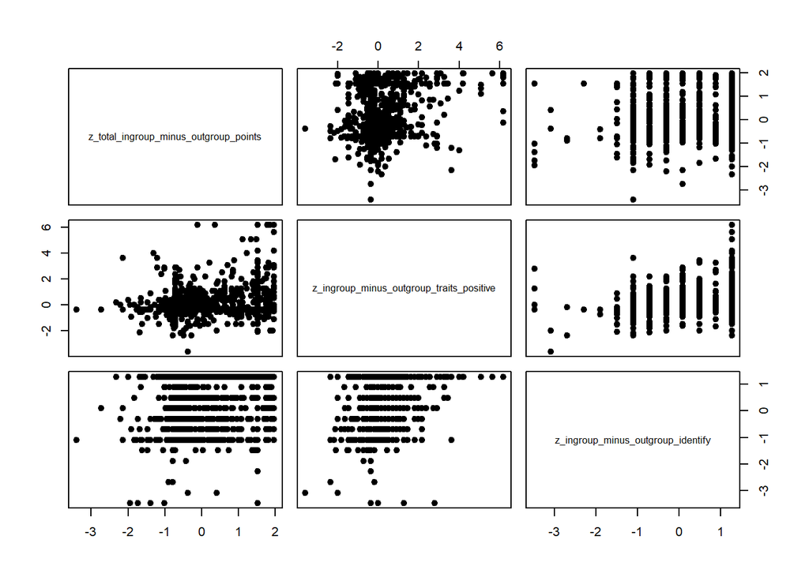

```r
plot(nhb3[, c("z_total_ingroup_minus_outgroup_points",
               "z_ingroup_minus_outgroup_traits_positive",
               "z_ingroup_minus_outgroup_identify")], pch=19)
```

## System information (for reproducibility)

```r
Sys.info()[1:3]
```

```
##       sysname       release       version
##     "Windows"      "10 x64" "build 22631"
```